# Assignment 3

```r
source('main.R')
```

## Setup

Feel free to refer to the reference_report.html provided in the assignment repo. This will let you see a preview of the output the report is intended to generate, and this will be especially helpful for the sections that create plots. The example report also displays the first few rows of all the data you will be generating in each section for your reference.

This assignment will make use of the [RColorBrewer](https://www.r-graph-gallery.com/38-rcolorbrewers-palettes.html) package to choose an appropriate color palette for a heatmap in part 8. Please make sure to install this package before starting.

We will be using three main datasets that are contained within the repo:

1. example_intensity_data.csv - a dataframe containing the normalized intensity values from a microarray experiment
2. proj_metadata.csv - a dataframe containing the associated metadata for the samples of the experiment
3. differential_expression_results.csv - a dataframe containing the results of a differential expression analysis on the probes from this experiment.

## 1. Read in the example_intensity_data

To begin, we will read in the same data you have used in previous experiments (`example_intensity_data.csv`). This time, we do **not** want to read it in as a tibble as some of our downstream operations will not work correctly without additional steps.

**Write a function, `read_data`, that reads in the example_intensity_data.csv as a *dataframe*. Return the first two rows of the dataframe below**:

```r
intensity <- read_data('example_intensity_data.csv', ' ')
head(intensity, 2)
```

```
##           GSM972389 GSM972390 GSM972396 GSM972401 GSM972409 GSM972412 GSM972413
## 1007_s_at  9.540293 10.196316  9.717891  9.679786  9.345668  9.891943  9.701660
## 1053_at    7.624984  7.923407  7.168436  7.241509  8.195539  6.865943  6.615046
##           GSM972422 GSM972429 GSM972433 GSM972438 GSM972440 GSM972443 GSM972444
## 1007_s_at  9.669885  9.874803  8.881964  9.059491  9.694206  9.620719 10.407125
## 1053_at    7.234132  7.450224  7.491488  7.058066  7.260983  8.043231  8.073587
##           GSM972446 GSM972453 GSM972457 GSM972459 GSM972463 GSM972467 GSM972472
## 1007_s_at  9.600054  9.540551 10.219165  9.290572 10.147639  9.572169  9.968517
## 1053_at    7.522149  7.953789  7.231532  6.847490  6.840958  7.121519  7.070082
##           GSM972473 GSM972475 GSM972476 GSM972477 GSM972479 GSM972480 GSM972487
## 1007_s_at  9.599155  9.550871  9.933563  9.928343  9.266313  9.842730  9.973421
## 1053_at    8.420469  7.668021  7.318720  8.004061  6.714915  7.411388  6.844783
##           GSM972488 GSM972489 GSM972496 GSM972502 GSM972510 GSM972512 GSM972521
## 1007_s_at  9.824724 10.023995  9.816108 10.165726  9.472485 10.136710  9.525885
## 1053_at    7.972273  7.522473  7.498586  7.598142  6.551502  7.554486  7.364664
```

### Background on PCA

PCA is an exploratory data analysis technique commonly used to reduce the dimensionality of data while simultaneously minimizing information loss. Understanding the inner workings of PCA will require an in-depth review of linear algebra and is beyond the scope of this specific assignment. We will provide several links and references if you wish to do so on your own. At its core, PCA creates new uncorrelated linear combinations of the original variables that successively maximize variance. Thus, the first principle component (PC) represents the direction of the data that explains a maximal amount of variance. The second PC represents the direction that captures the second most variance and so on and so forth. As you can infer, if a small number of PCs capture a majority of variance contained within a dataset, they can be used as a lower dimensional representation of the data.

Before we perform PCA, we will transpose and scale our data. These topics are covered in more detail in the course textbook and they are already implemented in R as the base functions `t()` and `scale()`. First, we will transpose the dataframe we generated in part 1 and scale the values before performing PCA using `prcomp()`.

*Hint*: The `prcomp()` function has flags to center and scale data. As we have already scaled our data, we will set both the center and scale flags to FALSE.

**Run the code below as is to perform PCA on your dataframe that you read in above.**

```r
pca_results <- prcomp(scale(t(intensity)), center=FALSE, scale=FALSE)
summary(pca_results)
```

```
## Importance of components:
##                            PC1      PC2      PC3      PC4     PC5      PC6
## Standard deviation     89.2094 72.22990 61.89247 55.57372 51.0175 46.12430
## Proportion of Variance  0.1456  0.09542  0.07006  0.05649  0.0476  0.03891
## Cumulative Proportion   0.1456  0.24098  0.31104  0.36753  0.4151  0.45404
##                             PC7      PC8      PC9     PC10     PC11     PC12
## Standard deviation     43.07422 42.68533 41.50551 40.12095 39.08442 37.63596
## Proportion of Variance  0.03393  0.03332  0.03151  0.02944  0.02794  0.02591
## Cumulative Proportion   0.48798  0.52130  0.55281  0.58225  0.61019  0.63610
##                            PC13     PC14     PC15     PC16    PC17     PC18
## Standard deviation     37.01491 36.08106 34.88482 34.38496 33.9638 33.01565
## Proportion of Variance  0.02506  0.02381  0.02226  0.02162  0.0211  0.01994
## Cumulative Proportion   0.66116  0.68497  0.70723  0.72885  0.7500  0.76989
##                           PC19     PC20     PC21     PC22     PC23     PC24
## Standard deviation     32.5668 31.79165 31.22997 31.07774 30.45561 30.23507
## Proportion of Variance  0.0194  0.01849  0.01784  0.01766  0.01696  0.01672
## Cumulative Proportion   0.7893  0.80777  0.82561  0.84327  0.86024  0.87696
##                            PC25     PC26     PC27     PC28     PC29     PC30
## Standard deviation     29.69602 29.22066 28.85579 28.45954 28.14335 27.83812
## Proportion of Variance  0.01613  0.01562  0.01523  0.01481  0.01449  0.01417
## Cumulative Proportion   0.89309  0.90870  0.92393  0.93875  0.95323  0.96741
##                           PC31     PC32     PC33     PC34      PC35
## Standard deviation     25.7185 24.35482 17.64543 14.69982 3.225e-13
## Proportion of Variance  0.0121  0.01085  0.00569  0.00395 0.000e+00
## Cumulative Proportion   0.9795  0.99035  0.99605  1.00000 1.000e+00
```

## 2. Calculating the variance explained by Principal Components

Now that we have performed PCA, we are interested in the proportion of variance explained by each principal component. This can be determined by dividing the variance of each PC by the sum total of the variance of all PCs.

**Write a function, `calculate_variance_explained`, that calculates the proportion of variance explained by each principal component from the `pca_results` object and returns a *vector* of those values below.**

*Hint*: The standard deviation values of each PC may be accessed by pca_results$sdev. Remember the relationship between standard deviation and variance.

```r
pc_variance_explained <- calculate_variance_explained(pca_results)
pc_variance_explained
```

```
##  [1] 1.455567e-01 9.542127e-02 7.006270e-02 5.648721e-02 4.760464e-02
##  [6] 3.891086e-02 3.393486e-02 3.332488e-02 3.150813e-02 2.944107e-02
## [11] 2.793950e-02 2.590701e-02 2.505905e-02 2.381057e-02 2.225790e-02
## [16] 2.162460e-02 2.109813e-02 1.993659e-02 1.939822e-02 1.848576e-02
## [21] 1.783834e-02 1.766485e-02 1.696468e-02 1.671987e-02 1.612901e-02
## [26] 1.561677e-02 1.522920e-02 1.481382e-02 1.448647e-02 1.417396e-02
## [31] 1.209765e-02 1.084878e-02 5.694763e-03 3.952166e-03 1.901674e-30
```

## 3. Make a tibble with variance explained and cumulative variance explained for the PCs

**Using the vector of variance explained values you just generated, `pc_variance_explained`, write a function, `make_variance_tibble`, that uses this vector along with the `pca_results` object to construct a *tibble* with three columns containing the name of each PC, the variance explained by each PC, and the cumulative sum of variance explained. Return the first five rows below.**

```r
variance_tibble <- make_variance_tibble(pc_variance_explained, pca_results)
head(variance_tibble, 5)
```

```
## # A tibble: 5 × 3
##   principal_components variance_explained cumulative
##   <fct>                             <dbl>      <dbl>
## 1 PC1                              0.146       0.146
## 2 PC2                              0.0954      0.241
## 3 PC3                              0.0701      0.311
## 4 PC4                              0.0565      0.368
## 5 PC5                              0.0476      0.415
```

### Create descriptive captions for plots here after you’ve finished

For the next few sections, we will be generating plots. It is customary to provide descriptive captions for figures that succinctly state what’s being displayed. Browse a few scientific papers of your choice to get a sense for how figure captions are structured and written. For the sections numbered 4, 5, 8, please use the following code block to write descriptive captions for these figures. We have assigned these captions to variables, and if you look at the `{r code}` chunk for these parts (4, 5, 8), you will notice the `fig.cap` flag which will use these variables to create captions underneath the respective figures. Until you’ve completed all the parts, you may safely leave these captions blank.

```r
caption_4 <- 'PCA Analysis - Proportion of Variance'
caption_5 <- 'PCA biplot with Subtype Classifications'
caption_8 <- 'Differentially Expressed Genes (p adjusted < 0.01)'
```

## 4. Plot the variance explained and cumulative variance for the PCs

**Write a function, `plot_pca_variance`, that uses the results generated in part 3, `variance_tibble`, and returns a *plot* that contains both a barchart representing the variance explained by each individual PC along with a scatterplot (connected with a line) that displays the cumulative sum of the variance explained across all the PCs. Provide appropriate labels for each plot.**

*Hint*: On your plot, you want the x-axis to represent each principal component in order of descending amounts of variance explained from left to right (i.e. PC1, PC2, PC3, etc.). You may run into an issue where your axis is automatically sorted differently. Please refer to discussions on lexicographical ordering vs. numeric ordering.

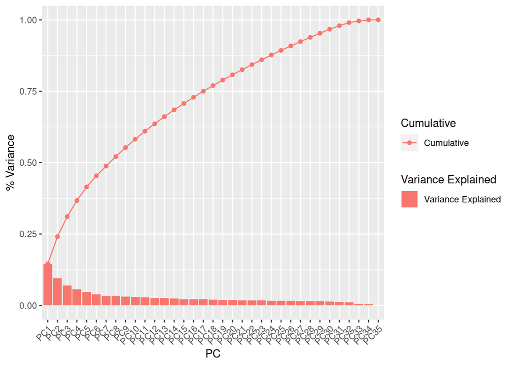

PCA Analysis - Proportion of Variance

```r
plot_pca_variance(variance_tibble)
```

## 5. Biplot of the first two principal components

As the first two PCs represent the first and second most amounts of variance, it is common to see scatter plots of the scores of the first two PCs for each sample. This biplot enables you to quickly see how your samples ‘separate’ across the PCs that represent (hopefully) the majority of variance in your data.

**Write a function, `make_biplot` that uses the `pca_results` generated in part 1 and returns a *plot* of the first two principal components labeled by their SixSubTypesClassification found in the `proj_metadata.csv`.**

*Hint*: You may access the values to plot by using `$x` (`pca_results$x`) and selecting the columns representing PC1 and PC2.

*Warning*: Since the first and second PCs likely represent different amounts of variance, visually interpreting these plots requires care as the scale of the ‘importance’ of the axes differ.

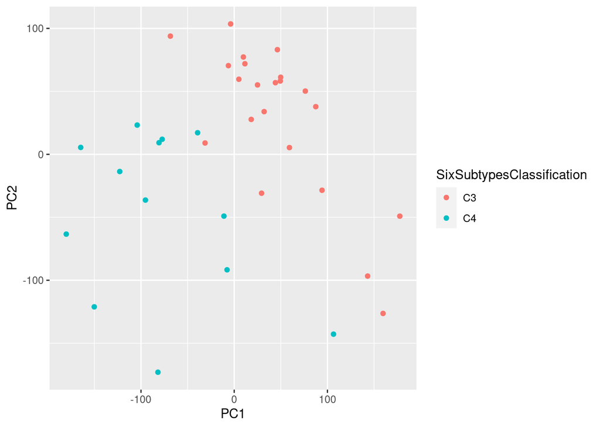

PCA biplot with Subtype Classifications

```r
make_biplot('proj_metadata.csv', pca_results)
```

## 6. Filter the differential_expression_results.csv for significant probes

We have provided you sample results of differential expression analysis performed on the intensity data from part 1. We are going to extract out a list of probes that are considered differentially expressed in this CSV and eventually generate a heatmap of the normalized intensity values for these selected probes.

**Write a function, `list_significant_probes`, that reads the differential_expression_results.csv, filters the data to only contain significant probes with a ‘padj’ of less than .01, and returns a *list* of the significant probe IDs**. Have your function define two arguments, the path to a CSV file (differential_expression_results.csv, in our case) and a user-specified value for the ‘padj’ threshold.

*Hint*: In general, it is a good practice to build functions that are flexible and do not contain hard-coded values so that you can reuse your function for different applications or analyses with minimal changes. For instance, we have you construct this function with a ‘padj’ value argument so that theoretically, in the future, you could easily re-run it with a different value. For our purposes, we will manually set this argument as .01.

```r
sig_ids <- list_significant_probes('differential_expression_results.csv', .01)
head(sig_ids)
```

```
## [1] "223121_s_at" "223122_s_at" "207266_x_at" "203748_x_at" "204457_s_at"
## [6] "209868_s_at"
```

```r
length(sig_ids)
```

```
## [1] 11972
```

## 7. Extract out the normalized intensity values for the significant probes

Now that we have a list of significant probes, we want to make a visualization, in the form of a heatmap, that will allow us to quickly determine if we see any patterns or clusters amongst these differentially expressed probes. To do this, we will extract out the intensity values from part 1 for these probes that are significantly differentially expressed in part 6 and plot them in a heatmap.

**Write a function, `return_de_intensity`, that uses the list of significant probes you generated in part 6 `sig_ids` and the example intensity data from part 1 `intensity` to return a *matrix* of intensity values for just the significant probes.**

```r
de_intensity <- return_de_intensity(intensity, sig_ids)
head(de_intensity, 2)
```

```
##           GSM972389 GSM972390 GSM972396 GSM972401 GSM972409 GSM972412 GSM972413
## 117_at     5.503802  5.564583  5.061198  7.436622  5.192701  5.718927  5.874645
## 1405_i_at  8.026138  7.469039  5.424094  7.212148  9.482103  6.790198  6.569983
##           GSM972422 GSM972429 GSM972433 GSM972438 GSM972440 GSM972443 GSM972444
## 117_at     6.149756  5.457124  5.104236   6.38399  6.526206  5.241991  5.581244
## 1405_i_at  8.497829  6.362854  7.349658   7.38762  7.971542  7.421006  9.006195
##           GSM972446 GSM972453 GSM972457 GSM972459 GSM972463 GSM972467 GSM972472
## 117_at     5.703034  4.895305  4.953531  5.398679  4.951501  5.482324  5.723044
## 1405_i_at  5.954797  5.865802  7.618981  4.995027  7.358917  7.348923  3.863973
##           GSM972473 GSM972475 GSM972476 GSM972477 GSM972479 GSM972480 GSM972487
## 117_at     5.049112  4.806533  5.098324  4.959627  9.107535  5.154134  4.823892
## 1405_i_at  6.663313  6.298672  5.478189  8.093300  6.249565  6.279790  6.477005
##           GSM972488 GSM972489 GSM972496 GSM972502 GSM972510 GSM972512 GSM972521
## 117_at     5.056084   5.08165  4.770242  4.846150  5.073056  5.523294  5.690338
## 1405_i_at  7.124877   8.37024  6.992560  5.631777  6.791859  5.996716  7.948122
```

## 8. Generate a heatmap of normalized intensity values (color-blind friendly)

*Hint*: Use the base R `heatmap()` function. For this example, we will only be passing two arguments: the `matrix` of normalized intensity values from part 7, and a color-blind friendly color palette. Look at the RColorBrewer documentation and choose a suitable palette. Your usage should look something like this: `heatmap(your_normalized_intensity_values, col = RColorBrewer_palette)`. The `heatmap()` function will automatically scale data as well as perform hierarchical clustering. For the purposes of this assignment, we will not go in-depth into these topics, and you will run `heatmap()` with default options besides `col`.

[figure not shown]

Differentially Expressed Genes (p adjusted < 0.01)

```r
plot_heatmap(de_intensity, 11, 'RdBu')
```